A major challenge I’ve encountered in creating individualized reproducible reports are placing tables side-by-side.

### Other Approaches

Side-by-side tables can be achieved in HTML by [coding a table](http://stackoverflow.com/questions/19237190/2-column-report-in-r-markdown-render-html-aside-data-frame), but I need to produce the report as a PDF.

The first method I found using `grid` graphics as outlined in the [vignette from `gridExtra`](https://cran.r-project.org/web/packages/gridExtra/vignettes/tableGrob.html). Building a design for your table can be cumbersome, and it took me a lot of trial-and-error to come up with this custom format.

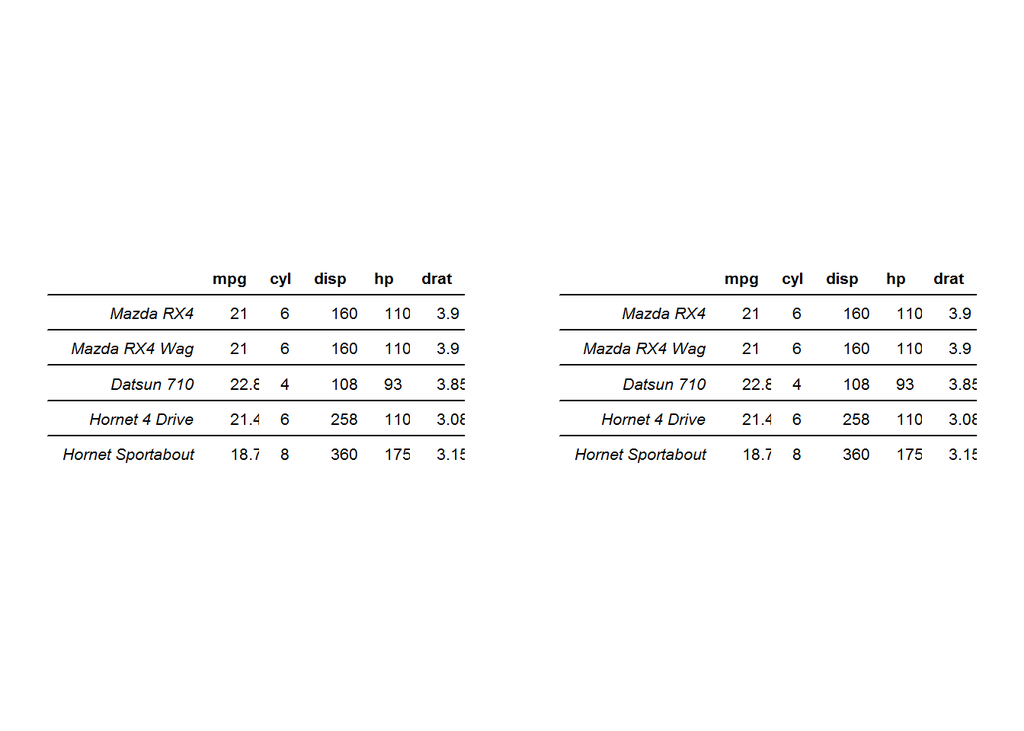

```r
library(grid)
library(gridExtra)
library(gtable)


CustomTable <- function(df, row.names = rownames(df), font.size = 8) {
     theme1 <- ttheme_minimal(
     core=list(fg_params=list(fontsize = font.size, hjust = 0)),
     colhead=list(fg_params=list(fontsize = font.size)),
     rowhead=list(fg_params=list(fontsize = font.size))
     )

     horiztonal <- replicate(nrow(df),
     segmentsGrob(
     x0 = unit(0,"npc"),
     y0 = unit(0,"npc"),
     x1 = unit(1,"npc"),
     y1 = unit(0,"npc"),
     gp = gpar(lwd = 1)),
     simplify = FALSE
     )

     g <- tableGrob(df, theme = theme1, rows = row.names)

     g <- gtable_add_grob(g, grobs = horiztonal,
     t = seq_len(nrow(g)-1), b = seq_len(nrow(g)-1), l = 1, r = ncol(g))

     g
}

my.table <- mtcars[1:5, 1:5]

grid.arrange(CustomTable(my.table), CustomTable(my.table), nrow = 1)
```

The difficulty I ran into using this method was when I tried to place the tables on the page, especially in relation to other elements, like a `pandoc.table`.

I found the second method at [StackOverflow](http://stackoverflow.com/questions/23926671/side-by-side-xtables-in-rmarkdown) involves writing the tables to file then placing them in the document. While effective, it’s not ideal when you’re creating two to four tables for five hundred individualized reports.

### Building a table with `Latex`

If you run `print(knitr::kable(my.table, format = 'latex'))` to the console, you can see the `Latex` syntax. Using [this syntax](https://www.sharelatex.com/learn/Tables#Combining_rows_and_columns), we can construct a container table and place our tables inside it.

In order to use `Latex` within a `R` code-block, I use `cat` and the chunk-option `results='asis'`. `cat` prints the code to the document and `results='asis'` makes sure the `Latex` is used in formatting the final document.

```r
    cat('\\begin{center}')
    cat('\\begin{tabular}{ c c }')
    cat('\\footnotesize')
    print(knitr::kable(my.table, format = 'latex'))
    cat('&')
    cat('\\footnotesize')
    print(knitr::kable(my.table, format = 'latex'))
    cat('\\end{tabular}')
    cat('\\end{center}')
```

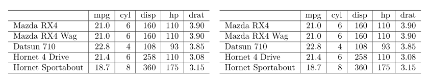

http://tex.stackexchange.com/questions/56008/different-sizes-of-font-available-in-table

https://www.sharelatex.com/learn/Font_sizes,_families,_and_styles

```r
    cat('\\begin{center}')
    cat('\\begin{tabular}{ c c }')
    cat('\\footnotesize')
    print(knitr::kable(my.table, format = 'latex'))
    cat('&')
    cat('\\footnotesize')
    print(knitr::kable(my.table, format = 'latex'))
    cat('\\end{tabular}')
    cat('\\end{center}')
```

[figure not shown]